# Data Challenge #2

### 1d did you find something interesting? what is that? does your finding

### suggest this question is worth pursuing further? why or why not?

```
* We found that the navy and the army seem to a statistically significant
and positive relationship to perfect lethality, controlling for all other
variables included in the model. This means that if the Army or Navy is
involved in an event the event has higher odds of being an event of perfect
lethality. I feel this finding does suggest this question is worth pursuing
further because it is important to know the effectivness of each individual
group to know what groups to send into specific situations.
```

### 1e if you did not find something interesting, explain why, and whether

### there is some additional information that would help in answering your question

### 1f provide your code, and a single visualization per question that summarizes

### your finding

```r
library(popbio)
```

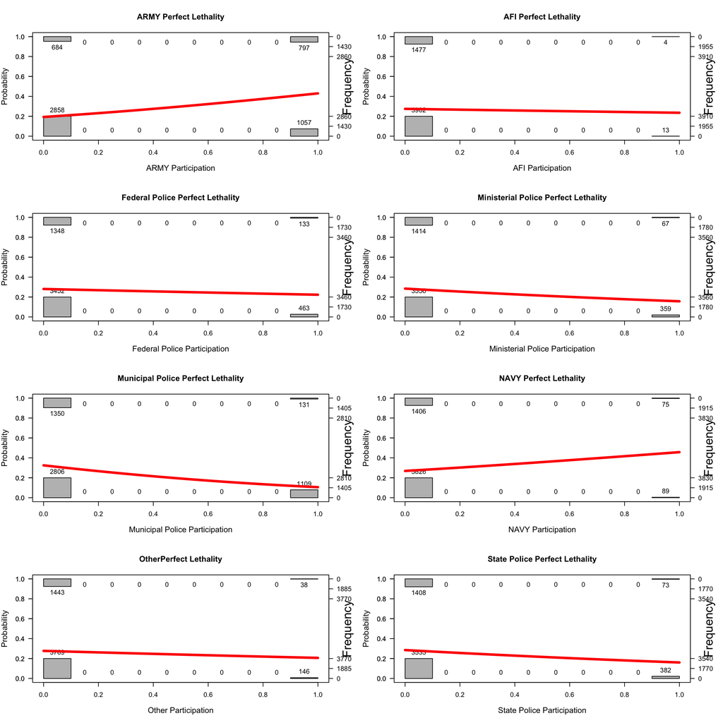

```r
par(mfrow = c(4, 2))

logi.hist.plot(AllData$army,
               AllData$perfect.lethality,
               boxp = FALSE,
               rug = FALSE,
               logi.mod = 1,
               type = "hist",
               col = "gray",
               counts = TRUE,
               mainlabel = "ARMY Perfect Lethality",
               xlabel = "ARMY Participation")

logi.hist.plot(AllData$afi,
               AllData$perfect.lethality,
               boxp = FALSE,
               rug = FALSE,
               logi.mod = 1,
               type = "hist",
               col = "gray",
               counts = TRUE,
               mainlabel = "AFI Perfect Lethality",
               xlabel = "AFI Participation")

logi.hist.plot(AllData$federal.police,
               AllData$perfect.lethality,
               boxp = FALSE,
               rug = FALSE,
               logi.mod = 1,
               type = "hist",
               col="gray",
               counts = TRUE,
               mainlabel = "Federal Police Perfect Lethality",
               xlabel = "Federal Police Participation")

logi.hist.plot(AllData$ministerial.police,
               AllData$perfect.lethality,
               boxp = FALSE,
               rug = FALSE,
               logi.mod = 1,
               type = "hist",
               col = "gray",
               counts = TRUE,
               mainlabel = "Ministerial Police Perfect Lethality",
               xlabel = "Ministerial Police Participation")

logi.hist.plot(AllData$municipal.police,
               AllData$perfect.lethality,
               boxp = FALSE,
               rug = FALSE,
               logi.mod = 1,
               type = "hist",
               col = "gray",
               counts = TRUE,
               mainlabel = "Municipal Police Perfect Lethality",
               xlabel = "Municipal Police Participation")

logi.hist.plot(AllData$navy,
               AllData$perfect.lethality,
               boxp = FALSE,
               rug = FALSE,
               logi.mod = 1,
               type = "hist",
               col = "gray",
               counts = TRUE,
               mainlabel = "NAVY Perfect Lethality",
               xlabel = "NAVY Participation")

logi.hist.plot(AllData$other,
               AllData$perfect.lethality,
               boxp = FALSE,
               rug = FALSE,
               logi.mod = 1,
               type = "hist",
               col = "gray",
               counts = TRUE,
               mainlabel ="OtherPerfect Lethality" ,
               xlabel = "Other Participation")

logi.hist.plot(AllData$state.police,
               AllData$perfect.lethality,
               boxp = FALSE,
               rug = FALSE,
               logi.mod = 1,
               type = "hist",
               col = "gray",
               counts = TRUE,
               mainlabel = "State Police Perfect Lethality",
               xlabel = "State Police Participation")
```

### 1g phrase your finding for each question in two ways:

### 1g-1 one sentence that summarizes your insight

- The invovlment of the Navy or Army in an event on average increase the chances of said event being one of perfect lethality.

### 1h make sure to also include your code

- The code is included under each quetsion above.

# **Model #1 for question #2:**

### 2.) Formulate two (2) conditional hypotheses that you seek to investigate with

### the data. One of your hypotheses should condition on two variables (as the

### example on the slides), and the other should condition on three variables. [50 pts]

[output not shown]

### 2a) formulate each one of your hypotheses explicitly in substantive terms (as

### opposed to statistical terms) using 2-3 lines at most

### 2b) show exactly how each one of your hypotheses translates into the marginal

### effect that you will seek to estimate from the data

### 2c) show the output from your analysis in a consumable form

### 2dv show all your computations to estimate the corresponding marginal effect

### 2e) be explicit in your assumptions

### 2f be explicit in the limitations of your inferences

### 2g) phrase your finding for each question in two ways:

### 2g-1) one sentence that summarizes your insight

### 2g-2) one paragraph that reflects all nuance in your insight

### 2h) make sure to also include your code

# **Model #1 for question #2:**

### 2.) Formulate two (2) conditional hypotheses that you seek to investigate with

### the data. One of your hypotheses should condition on two variables (as the

### example on the slides), and the other should condition on three variables. [50 pts]

[output not shown]